# Homework 1

Ali İsmail Duman

18 Ekim 2018

## R Markdown

```
## Empty data.table (0 rows) of 11 cols: leagueId,matchId,home,away,score,date...
```

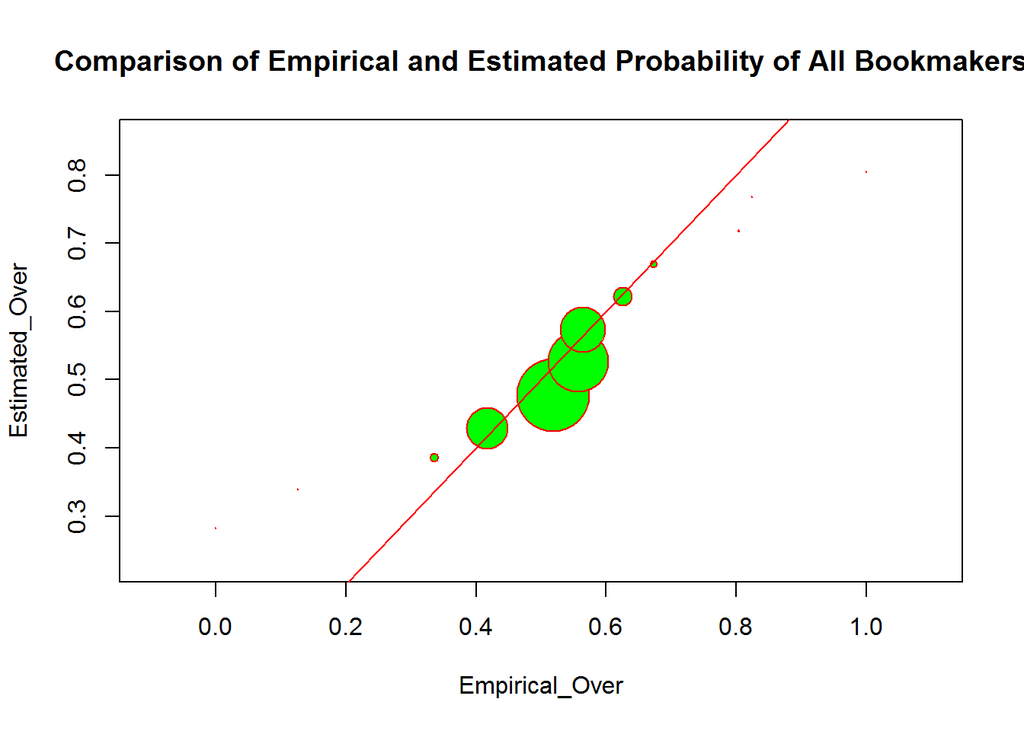

In this figure, all bookmakers are considered as a unique bookmaker. To construct the figure, final odds (over/under) of different bookmakers are transformed to probability by deviding each individual odd (over or under) to total probabilty. Then, obtained probabilities represent estimation of bookmakers. In order to examine success of bookmakers, the obtained probabilities are devided into bins. Finally, empirical probabilities which are obtained from real results are compared with estimated probability according to corresponding binds.

In the figure, size of the circles represents cumulation of data point in a specific bin, therefore bigger sizes contain more significant information. Additionally, x=y line is the line on which estimations and real results meet. Subsequently, a small deviation from x=y line around 0.5 probability is observed which can be interpreted as bookmakers are making slightly wrong estimation in the favor of winner, because more than estimated number of match had finished over around 0.5 probability.

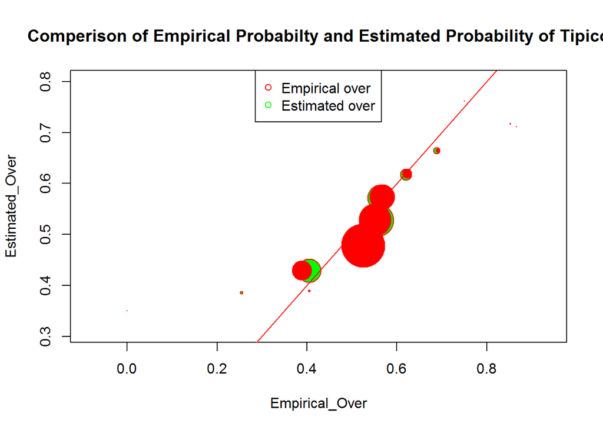

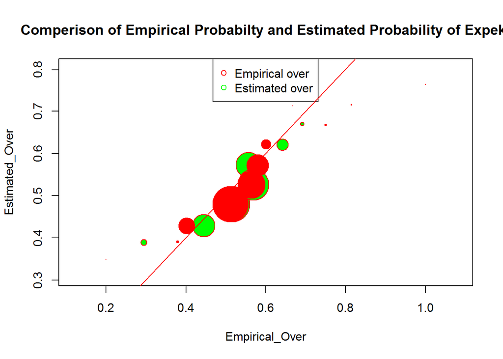

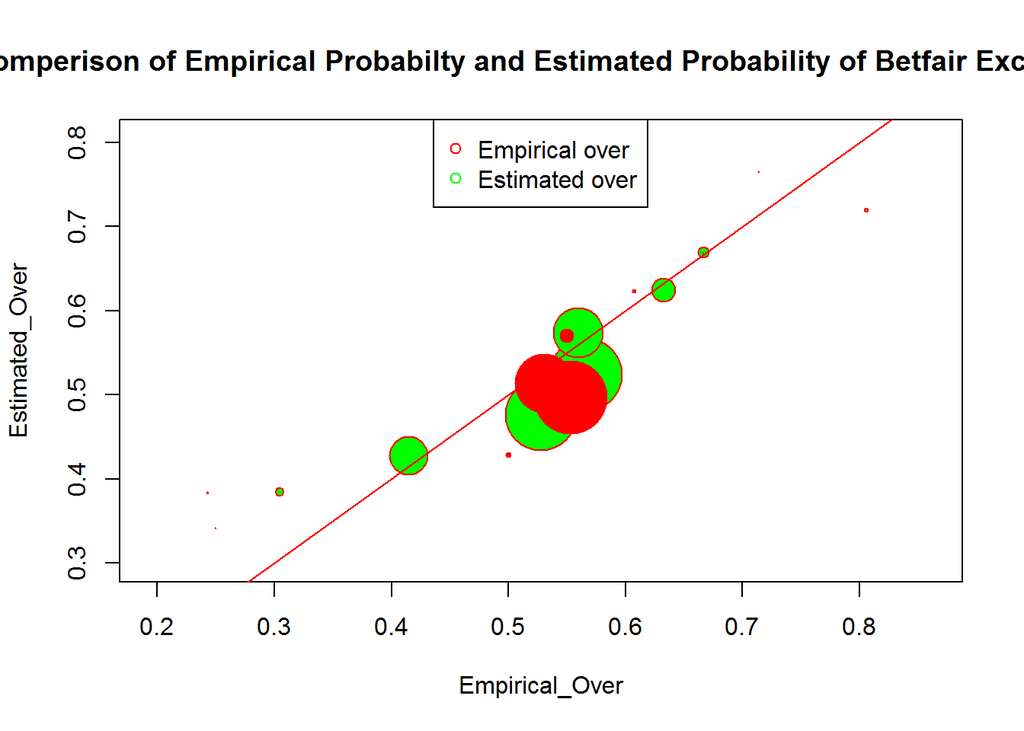

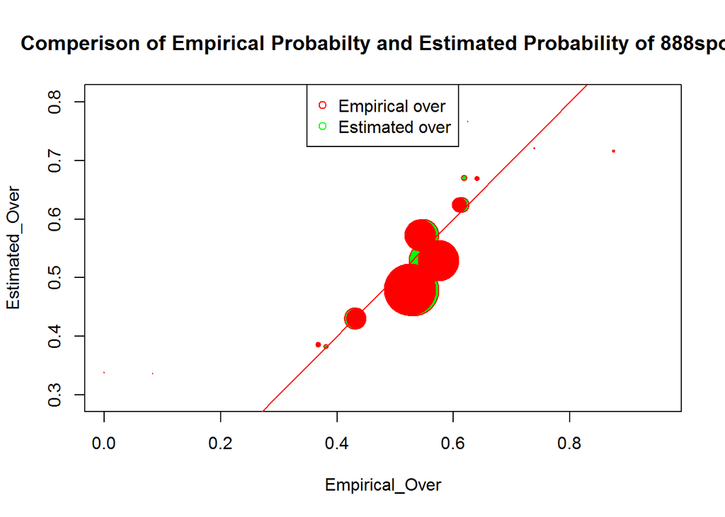

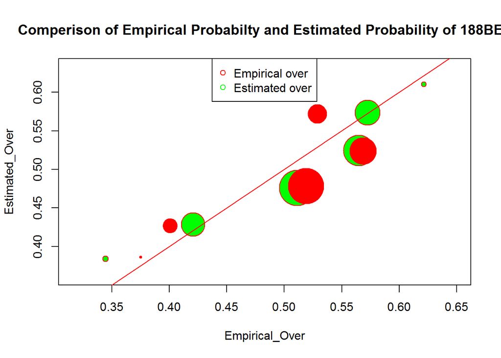

In the 5 figures above, 5 bookmakers are chosen randomly and, empirical over probability and estimated over probability (determined at two different times) are plotted. It is hard to deduce meaningful information from figures, however it can be said that new probabilities obtained from updated odds are distributed along the x=y line. Therefore, it may be reached that bookmarkers initially equally distribure possibilities between over and under odds ,then rearrange possibilities according to bettors’ tendency.

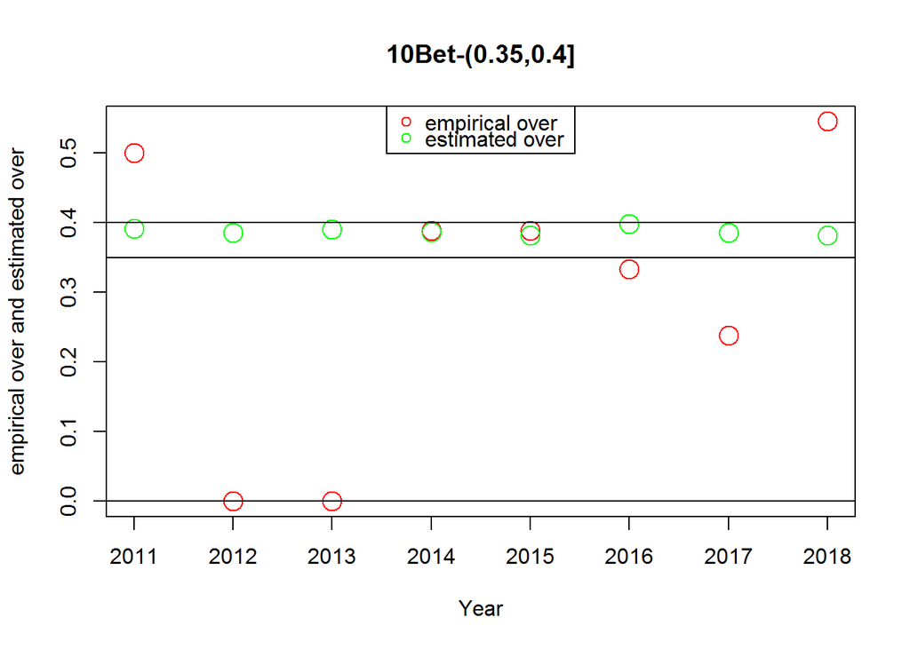

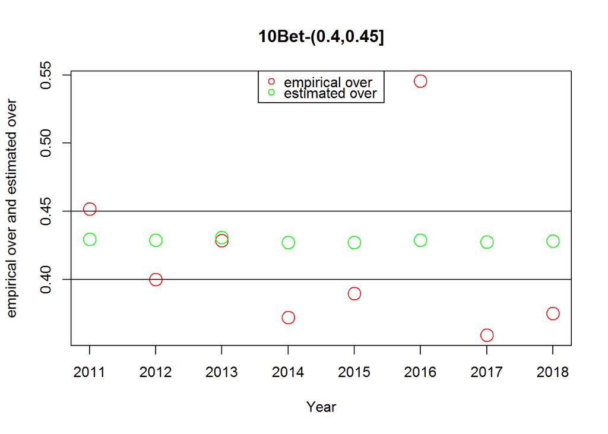

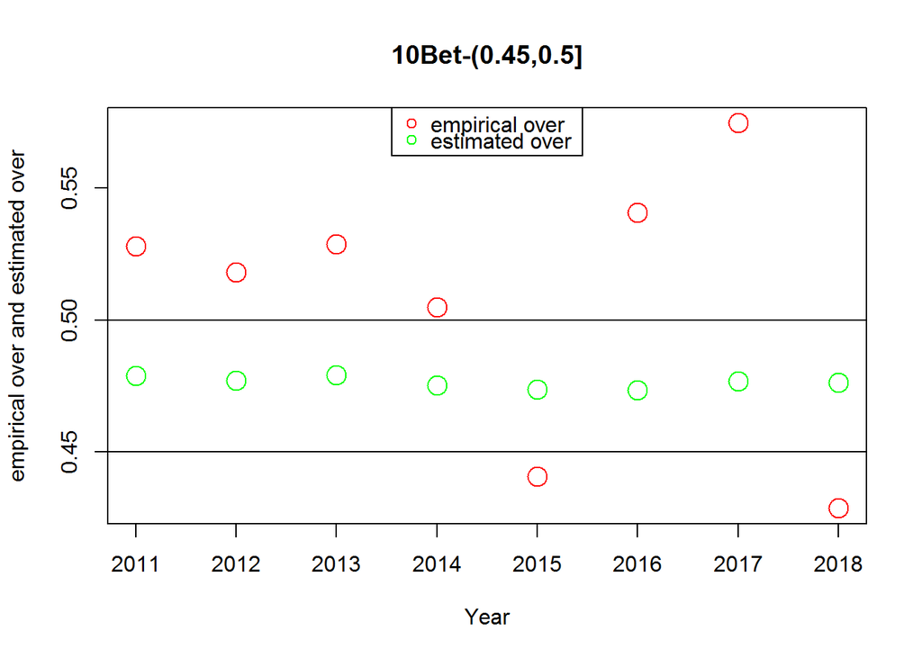

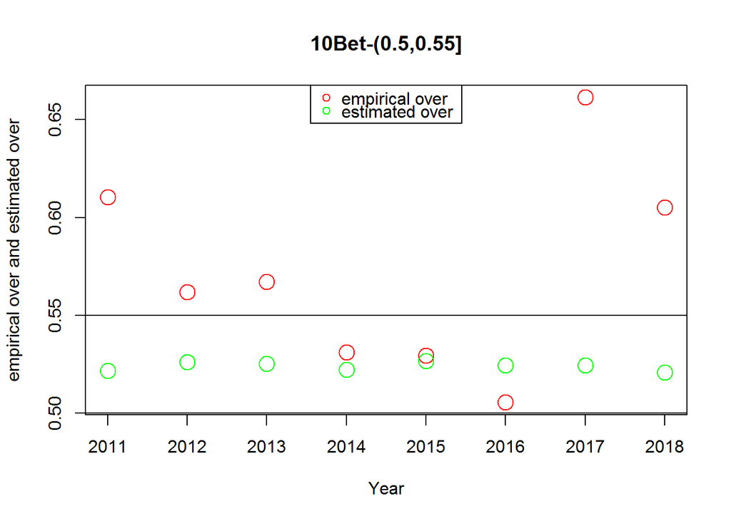

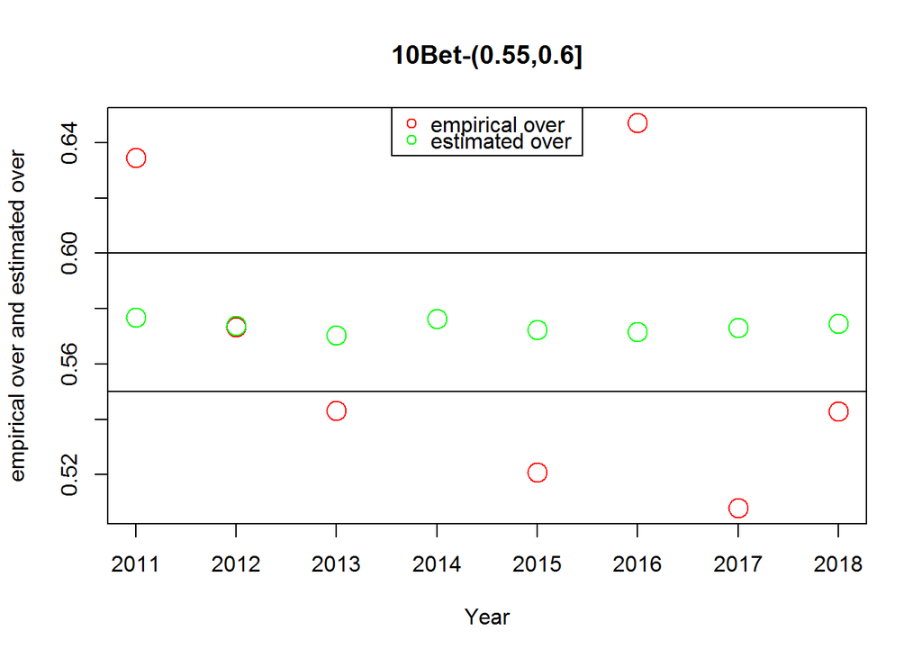

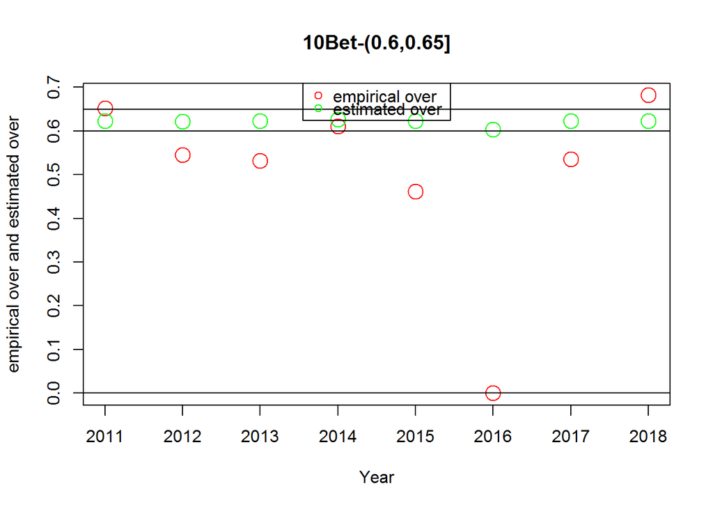

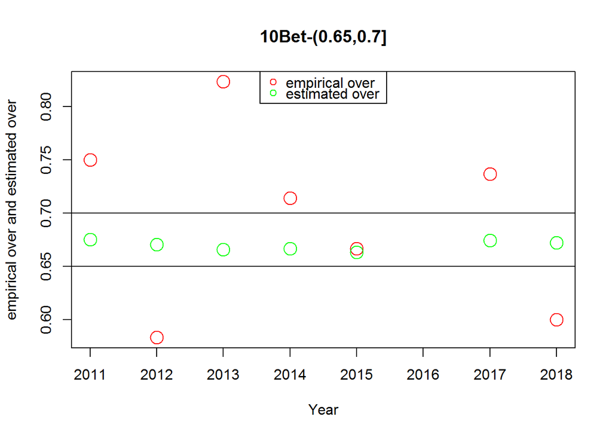

In the 7 scatters plots, empirical over probabilities and estimated over probabilities of a randomly chosen bookmaker (10Bet) are plotted for different bins. Additionally, two lines are added to each figures to show borders of each bins.

For (0.35,0.4] bin, the bookmaker catched the empirical probability at 2014 and 2015, it is not sharp in the other years.

For (0.45,0.5] bin, the bookmaker fails to catch empirical over probabilities. It can be said that estimated over probabilities are under empirical over probabilities.

For (0.5,0.55] bin, the bookmaker catched the empirical probability at 2014, 2015 and 2016. It can be said that estimated over probabilities are under empirical over probabilities at 2011, 2012, 2013, 2017 and 2018.

For (0.55,0.6] bin, the bookmaker catched the empirical probability at 2012. It can be said that estimated over probabilities are generally upon empirical over probabilities in other years.

For (0.65,0.7] bin, the bookmaker catched the empirical probability at 2015. It can be said that estimated over probabilities are under empirical over probabilities at 2011, 2013, 2014 and 2017.

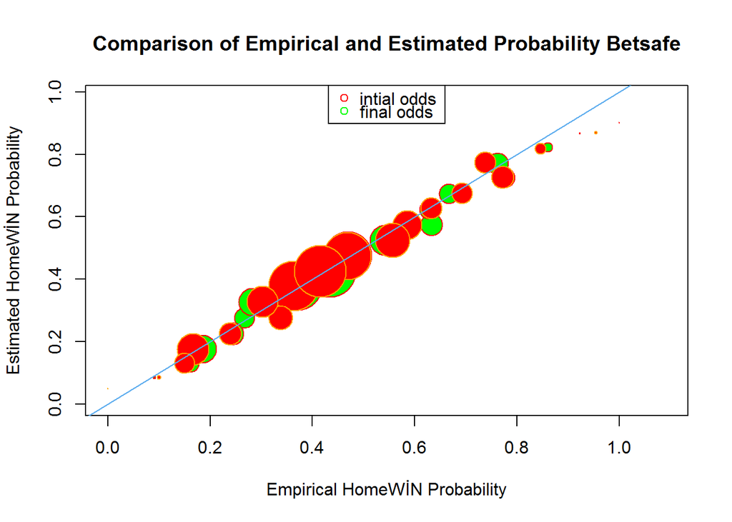

Betsafe has been succesful in determining odds of games and it is not posibble to deduce meaningful information for changes in odds during time.